# Esercitazione N.9

Author

Econometria

# Regressione con variabile dipendente binaria

**Pacchetti necessari:**

```r
library(tidyverse)
library(knitr)
library(kableExtra)
library(modelsummary)
library(fixest)
library(wooldridge)
```

Carichiamo i dati `alcohol` che contengono 9822 osservazioni e 33 variabili.

```r
data("alcohol", package = "wooldridge")
head(alcohol)
```

```
  abuse status unemrate age educ married famsize white exhealth vghealth
1     1      1      4.0  50    4       1       1     1        0        0
2     0      3      4.0  37   12       1       5     1        0        0
3     0      3      4.0  53    9       1       3     1        1        0
4     0      3      3.3  59   11       1       1     1        1        0
5     0      3      3.3  43   10       1       1     1        1        0
6     0      3      3.3  38   10       1       1     1        1        0
  goodhealth fairhealth northeast midwest south centcity outercity qrt1 qrt2
1          0          0         0       1     0        0         0    1    0
2          1          0         0       1     0        0         0    1    0
3          0          0         0       1     0        0         0    1    0
4          0          0         1       0     0        1         0    1    0
5          0          0         1       0     0        1         0    1    0
6          0          0         1       0     0        1         0    1    0
  qrt3 beertax cigtax ethanol mothalc fathalc livealc inwf employ agesq
1    0   0.334     38 2.03946       0       0       0    0      0  2500
2    0   0.334     38 2.03946       0       0       0    1      1  1369
3    0   0.334     38 2.03946       0       0       0    1      1  2809
4    0   0.240     26 2.44998       0       0       0    1      1  3481
5    0   0.240     26 2.44998       0       1       1    1      1  1849
6    0   0.240     26 2.44998       0       0       0    1      1  1444
  beertaxsq cigtaxsq ethanolsq educsq
1  0.111556     1444  4.159397     16
2  0.111556     1444  4.159397    144
3  0.111556     1444  4.159397     81
4  0.057600      676  6.002402    121
5  0.057600      676  6.002402    100
6  0.057600      676  6.002402    100
```

### Descrizione della variabili

| Variabile | Descrizione |
| --- | --- |
| $abuse$ | Variabile dummy (1=Abusa di Alcol, 0=Non abusa). |
| $employ$ | Variabile dipendente dummy (1=Occupato, 0=Non occupato). |
| $married$ | Variabile dummy (1=Sposato, 0=Non sposato). |
| $educ$ | Anni di istruzione |

In altre parole, la nostra variabile dipendente, $Y$, assume solo due valori: zero e uno (0 - 1).

Unique

Missing Pct.

Mean

SD

Min

Median

Max

Histogram

abuse

2

0

0.1

0.3

0.0

0.0

1.0

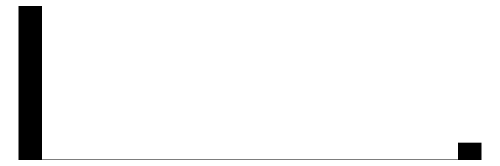

status

3

0

2.8

0.5

1.0

3.0

3.0

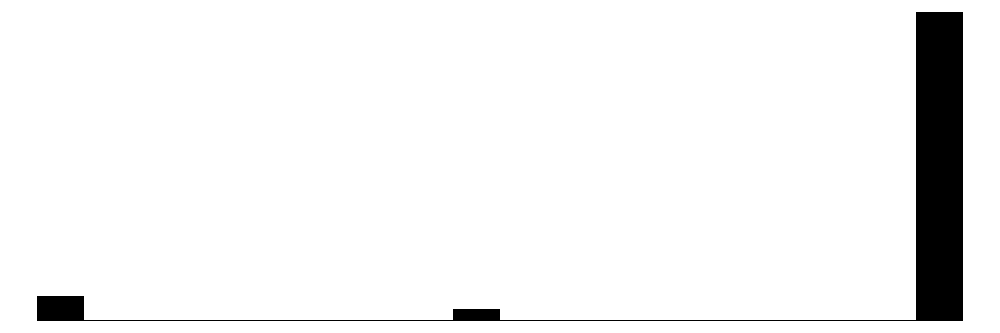

unemrate

35

0

5.6

1.5

2.8

5.3

10.9

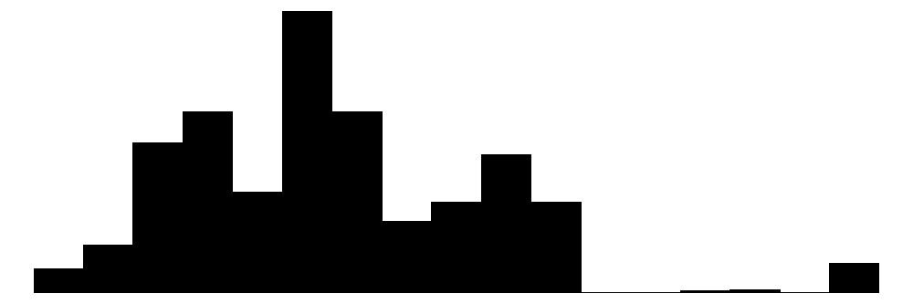

age

35

0

39.2

9.6

25.0

38.0

59.0

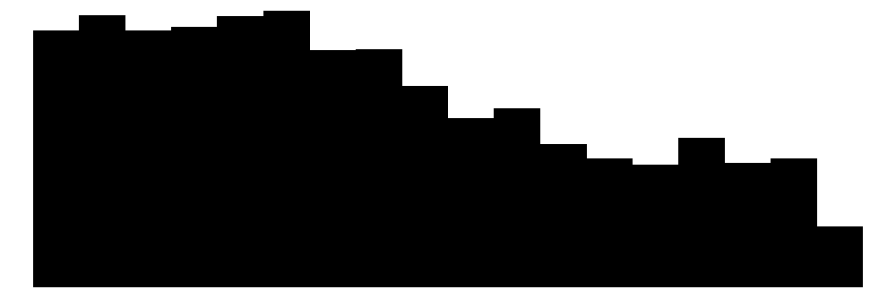

educ

20

0

13.3

2.9

0.0

13.0

19.0

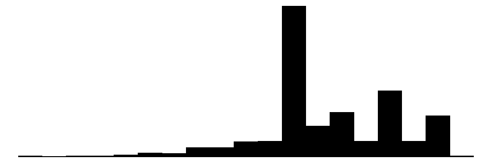

married

2

0

0.8

0.4

0.0

1.0

1.0

[figure not shown]

famsize

13

0

2.7

1.5

1.0

3.0

13.0

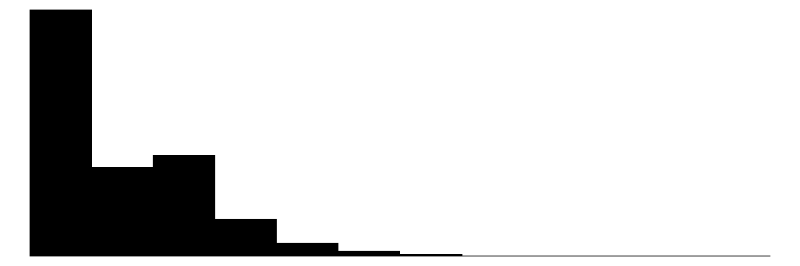

white

2

0

0.9

0.4

0.0

1.0

1.0

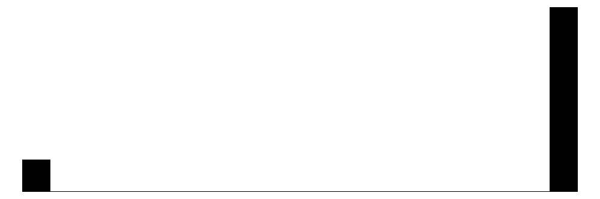

exhealth

2

0

0.4

0.5

0.0

0.0

1.0

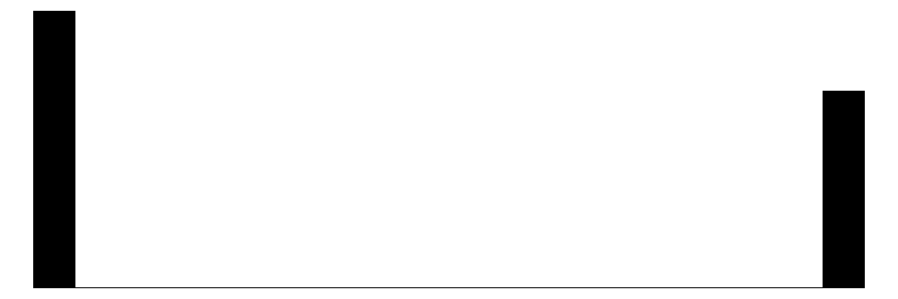

vghealth

2

0

0.3

0.5

0.0

0.0

1.0

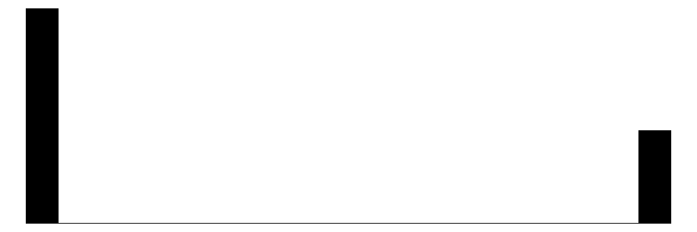

goodhealth

2

0

0.2

0.4

0.0

0.0

1.0

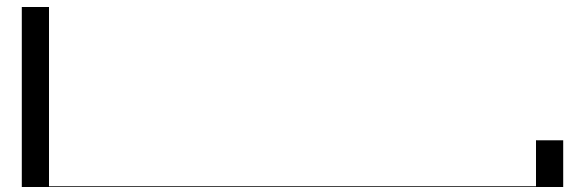

fairhealth

2

0

0.1

0.2

0.0

0.0

1.0

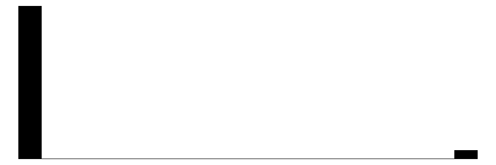

northeast

2

0

0.2

0.4

0.0

0.0

1.0

[21 more figures not shown]

```r
datasummary_skim(alcohol)
```

## Linear Probability Model (LPM)

Stimiamo il seguente modello di probabilità lineare (LPM) che asssume una relazione lineare tra le variabili esplicative e la probabilità dell’evento:
$$\Pr(Y=1|X_1,\dots, X_k) = \beta_0 + \beta_1 X_1 + \beta_2 X_2 + ... + \beta_k X_k$$

Implicazione, sotto assunzione $E(u_i | X_i) = 0$:
$$\mathbb{E}(Y \mid X = x) = \Pr(Y = 1 \mid X = x)$$

cioè il valore atteso condizionato coincide con la probabilità che $Y = 1$ dato $X = x$.

$\beta_1$ rappresenta la variazione della probabilità che $Y = 1$ per una variazione unitaria in $X$, o più generalmente:

$$\beta_1 = \frac{\Pr(Y = 1 \mid X = x + \Delta x) - \Pr(Y = 1 \mid X = x)}{\Delta x}$$

La procedura di stima tramite OLS resta invariata.

Il LPM è semplice da stimare e interpretare. Tuttavia, può produrre probabilità previste inferiori a zero o superiori a uno e gli effetti marginali sono costanti.

Per i modelli LPM vengono riportati errori standard robusti `vcoc= hetero`.

**Attenzione**

**Importante:** **L’eteroschedasticità** è intrinseca nel LPM.

```r
reg_lpm_alcohol <- feols(employ ~ abuse + educ + age + married, data = alcohol, vcov = "hetero")
modelsummary(list("Employ" = reg_lpm_alcohol), output = "markdown", gof_omit = "AIC|BIC|RMSE")
```

|  | Employ |
| --- | --- |
| (Intercept) | 0.741 |
|  | (0.022) |
| abuse | -0.018 |
|  | (0.011) |
| educ | 0.017 |
|  | (0.001) |
| age | -0.003 |
|  | (0.000) |
| married | 0.084 |
|  | (0.009) |
| Num.Obs. | 9822 |
| R2 | 0.045 |
| R2 Adj. | 0.045 |
| Std.Errors | Heteroskedasticity-robust |

**Interpretazione dei coefficienti:**

- il coefficiente − 0.018 di $abuse$. Aver abusato di alcol è associato ad una probabilità di essere occupato **inferiore** di circa 1.8 punti percentuali rispetto a un uomo che non ha abusato di alcol. A parità di età, anni di istruzione e stato coniugale.
- il coefficiente 0.017. Ogni anno in più di istruzione è associato ad un **aumento** della probabilità di essere occupato di 1.7 punti percentuali. A parità di età, abuso di alcol e stato coniugale.

**Nota:** Attenzioni alle variabili percentuali espresse in forma decimale (0.26). Ad esempio `pirat` (Rapporto tra pagamenti e reddito) nella Lezione *Analisi della Concessione di Mutui su dati HMDA*.

## Probit e Logit

**Modello Logit**: Utilizza la funzione logistica per modellare la probabilità:
$$\Pr(Y=1|X_1,\dots, X_k) = \frac{e^{\beta_0 + \beta_1 X_1 + \beta_2 X_2 + ... + \beta_k X_k}}{1 + e^{\beta_0 + \beta_1 X_1 + \beta_2 X_2 + ... + \beta_k X_k}} = \Lambda(X\beta)$$

dove $\Lambda(z) = \frac{e^z}{1 + e^z}$ è la funzione logistica.

**Modello Probit**: Utilizza la funzione di distribuzione cumulativa normale:
$$\Pr(Y=1|X_1,\dots, X_k) = \Phi(\beta_0 + \beta_1 X_1 + \beta_2 X_2 + ... + \beta_k X_k) = \Phi(X\beta)$$

dove $\Phi(z)$ è la funzione di distribuzione cumulativa della normale standard.

I modelli Logit e Probit vengono stimati con il metodo della massima verosimiglianza (MLE).

Sia per Logit che per Probit, i coefficienti stimati **non rappresentano** direttamente gli effetti marginali, che invece variano a seconda dei valori delle variabili esplicative. L’effetto marginale dipende dai valori di tutte le variabili esplicative, a differenza del linear probability model (LPM) dove è costante.

```r
probit_alcohol <- feglm(employ ~ abuse + educ + age + married, data = alcohol, family = 'probit')

logit_alcohol <- feglm(employ ~ abuse + educ + age + married, data = alcohol, family = 'logit')

modelsummary(list("Employ (LPM)" = reg_lpm_alcohol, "Employ (Probit)" = probit_alcohol, "Employ (Logit)"=logit_alcohol), output = "markdown", gof_omit = "AIC|BIC|RMSE")
```

|  | Employ (LPM) | Employ (Probit) | Employ (Logit) |
| --- | --- | --- | --- |
| (Intercept) | 0.741 | 0.495 | 0.802 |
|  | (0.022) | (0.114) | (0.216) |
| abuse | -0.018 | -0.110 | -0.223 |
|  | (0.011) | (0.056) | (0.105) |
| educ | 0.017 | 0.089 | 0.166 |
|  | (0.001) | (0.006) | (0.011) |
| age | -0.003 | -0.018 | -0.035 |
|  | (0.000) | (0.002) | (0.004) |
| married | 0.084 | 0.455 | 0.859 |
|  | (0.009) | (0.045) | (0.084) |
| Num.Obs. | 9822 | 9822 | 9822 |
| R2 | 0.045 | 0.064 | 0.064 |
| R2 Adj. | 0.045 | 0.063 | 0.063 |
| Std.Errors | Heteroskedasticity-robust | IID | IID |

## Effetti Marginali Medi (AME)

Il calcolo degli effetti marginali è fondamentale per interpretare correttamente i modelli Logit e Probit.

Si calcolano gli effetti marginali per ogni osservazione nel dataset e poi si fa la media.

Matematicamente, l’effetto marginale medio (AME) è calcolato come:
$$\overline{\text{ME}} = \frac{1}{n} \sum_{i=1}^{n} \text{ME}_i$$
dove $\text{ME}_i$ è l’effetto marginale calcolato per l’osservazione $i$ e $n$ è il numero totale di osservazioni nel dataset.

**Per il modello LPM**: L’effetto marginale è semplicemente il coefficiente $\beta_j$:
$$\frac{\partial \Pr(Y=1|X_1,\dots, X_k)}{\partial X_j} = \beta_j$$

### Calcolo manuale

Effetto Marginale abuso alcol, modello probit:

```r
# Creazione di due dataset: uno con abuse=1 per tutti e uno con abuse=0 per tutti
alcohol_tmp1 <- alcohol
alcohol_tmp0 <- alcohol

# Impostiamo abuse=1 per tutti nel primo dataset
alcohol_tmp1$abuse <- 1
# Impostiamo abuse=0 per tutti nel secondo dataset
alcohol_tmp0$abuse <- 0

# Calcolo delle probabilità predette per il modello logit
proba_employ_probit <- predict(probit_alcohol, newdata = alcohol_tmp1)
proba_nonemploy_probit <- predict(probit_alcohol, newdata = alcohol_tmp0)

# Calcolo dell'effetto marginale medio (differenza media nelle probabilità predette)
ame_manual_probit <- mean(proba_employ_probit - proba_nonemploy_probit)
print(paste("Effetto marginale medio manuale (Probit):", round(ame_manual_probit, 4)))
```

```
[1] "Effetto marginale medio manuale (Probit): -0.0194"
```

Per il modello logit:

```r
# Calcolo delle probabilità predette per il modello logit
proba_employ_logit <- predict(logit_alcohol, newdata = alcohol_tmp1)
proba_nonemploy_logit <- predict(logit_alcohol, newdata = alcohol_tmp0)

# Calcolo dell'effetto marginale medio (differenza media nelle probabilità predette)
ame_manual_logit <- mean(proba_employ_logit - proba_nonemploy_logit)
print(paste("Effetto marginale medio manuale (Logit):", round(ame_manual_logit, 4)))
```

```
[1] "Effetto marginale medio manuale (Logit): -0.0206"
```

- Secondo il modello Probit, abusare di alcol riduce la probabilità di essere occupato di 1.9 p.p.
- Secondo il modello Logit, abusare di alcol riduce la probabilità di essere occupato di 2.1 p.p.

L’approccio dell’effetto marginale medio è generalmente considerato più robusto, perché tiene conto di come l’effetto di $abuse$ può variare a seconda delle altre caratteristiche dei richiedenti.

### Con `marginaleffects`

Gli effetti marginali medi calcolati con `marginaleffects` sono identici a quelli calcolati manualmente in precedenza. Il vantaggio di utilizzare `marginaleffects` in questo caso è che otteniamo automaticamente anche gli errori standard permettendo una valutazione della significatività statistica dell’effetto.

La funzione `avg_slopes` senza l’opzione `newdata` calcola gli effetti marginali medi, ovvero calcola l’effetto marginale per ogni osservazione nel dataset e poi ne fa la media. Questo approccio tiene conto della distribuzione reale delle variabili nel campione.

```r
library(marginaleffects)
all_effects_logit <- avg_slopes(logit_alcohol)
all_effects_probit <- avg_slopes(probit_alcohol)
all_effects_probit
```

```
    Term Contrast Estimate Std. Error     z Pr(>|z|)     S   2.5 %    97.5 %
 abuse      1 - 0 -0.01939   0.010338 -1.88   0.0607   4.0 -0.0397  0.000869
 age        dY/dX -0.00298   0.000313 -9.53   <0.001  69.1 -0.0036 -0.002370
 educ       dY/dX  0.01492   0.000998 14.95   <0.001 165.4  0.0130  0.016873
 married    1 - 0  0.08945   0.010104  8.85   <0.001  60.0  0.0696  0.109250

Type:  response
```

```r
# Tabella elegante con modelsummary
modelsummary(list("Logit (AME)" = all_effects_logit, "Probit (AME)" = all_effects_probit), output = "markdown", gof_omit = "AIC|BIC|RMSE|R2|Adj")
```

|  | Logit (AME) | Probit (AME) |
| --- | --- | --- |
| abuse | -0.021 | -0.019 |
|  | (0.010) | (0.010) |
| age | -0.003 | -0.003 |
|  | (0.000) | (0.000) |
| educ | 0.014 | 0.015 |
|  | (0.001) | (0.001) |
| married | 0.091 | 0.089 |
|  | (0.010) | (0.010) |
| Num.Obs. | 9822 | 9822 |

Gli effetti sono vicini a quelli stimati con il modello LPM.

**Interpretazione** degli effetti marginali medi (AME) del modello Probit:

- Aver abusato di alcol riduce la probabilità di essere occupati di 1.9 punti percentuali
- Un anno in più di istruzione aumenta la probabilità di essere occupati 1.5 punti percenutali
- Essere sposato aumenta la probabilità di essere occupato di 8.9 punti percentuali